# Exercise 11/12

Author

Kelbi Hall

Published

March 12, 2025

Part 1: Normality Testing

```r
?airquality
```

```r
str(airquality)
```

```
'data.frame':   153 obs. of  6 variables:
 $ Ozone  : int  41 36 12 18 NA 28 23 19 8 NA ...
 $ Solar.R: int  190 118 149 313 NA NA 299 99 19 194 ...
 $ Wind   : num  7.4 8 12.6 11.5 14.3 14.9 8.6 13.8 20.1 8.6 ...
 $ Temp   : int  67 72 74 62 56 66 65 59 61 69 ...
 $ Month  : int  5 5 5 5 5 5 5 5 5 5 ...
 $ Day    : int  1 2 3 4 5 6 7 8 9 10 ...
```

```r
summary(airquality)
```

```
     Ozone           Solar.R           Wind             Temp
 Min.   :  1.00   Min.   :  7.0   Min.   : 1.700   Min.   :56.00
 1st Qu.: 18.00   1st Qu.:115.8   1st Qu.: 7.400   1st Qu.:72.00
 Median : 31.50   Median :205.0   Median : 9.700   Median :79.00
 Mean   : 42.13   Mean   :185.9   Mean   : 9.958   Mean   :77.88
 3rd Qu.: 63.25   3rd Qu.:258.8   3rd Qu.:11.500   3rd Qu.:85.00
 Max.   :168.00   Max.   :334.0   Max.   :20.700   Max.   :97.00
 NA's   :37       NA's   :7
     Month            Day
 Min.   :5.000   Min.   : 1.0
 1st Qu.:6.000   1st Qu.: 8.0
 Median :7.000   Median :16.0
 Mean   :6.993   Mean   :15.8
 3rd Qu.:8.000   3rd Qu.:23.0
 Max.   :9.000   Max.   :31.0
```

```r
head(airquality)
```

```
  Ozone Solar.R Wind Temp Month Day
1    41     190  7.4   67     5   1
2    36     118  8.0   72     5   2
3    12     149 12.6   74     5   3
4    18     313 11.5   62     5   4
5    NA      NA 14.3   56     5   5
6    28      NA 14.9   66     5   6
```

```r
shapiro.test(na.omit(airquality$Ozone))
```

```
    Shapiro-Wilk normality test

data:  na.omit(airquality$Ozone)
W = 0.87867, p-value = 2.79e-08
```

```r
shapiro.test(na.omit(airquality$Solar.R))
```

```
    Shapiro-Wilk normality test

data:  na.omit(airquality$Solar.R)
W = 0.94183, p-value = 9.492e-06
```

```r
shapiro.test(na.omit(airquality$Wind))
```

```
    Shapiro-Wilk normality test

data:  na.omit(airquality$Wind)
W = 0.98575, p-value = 0.1178
```

```r
shapiro.test(na.omit(airquality$Temp))
```

```
    Shapiro-Wilk normality test

data:  na.omit(airquality$Temp)
W = 0.97617, p-value = 0.009319
```

What is the purpose of the Shapiro-Wilk test?

The test determinds if the data has a normal distribution or not, which is imporant because we know if we can use statstical test like t-tests that assumes normaility.

What are the null and alternative hypotheses for this test?

The null hypothesis for this test is that the data is normally disrrbuted, while the alternative hypothesis is that the data is not normally distributed.

Interpret the p-values. Are these variables normally distributed?

Ozone: Not normally distributed Temp: Not normally distributed Solar: Not normally distributed Wind: Normally distributed

Part 2: Data Transformation and Feature Engineering

```r
library(dplyr)
airquality <- airquality %>%
  mutate(Season = case_when(
    Month %in% c(11, 12, 1) ~ "Winter",
    Month %in% c(2, 3, 4) ~ "Spring",
    Month %in% c(5, 6, 7) ~ "Summer",
    Month %in% c(8, 9, 10) ~ "Fall"
  ))

head(airquality)
```

```
  Ozone Solar.R Wind Temp Month Day Season
1    41     190  7.4   67     5   1 Summer
2    36     118  8.0   72     5   2 Summer
3    12     149 12.6   74     5   3 Summer
4    18     313 11.5   62     5   4 Summer
5    NA      NA 14.3   56     5   5 Summer
6    28      NA 14.9   66     5   6 Summer
```

```r
table(airquality$Season)
```

```
  Fall Summer
    61     92
```

Part 3: Data Preprocessing

```r
library(tidymodels)
library(dplyr)
```

```r
data("airquality")

airquality_recipe <- recipe(~ Temp + Solar.R + Wind, data = airquality) %>%
  step_impute_mean(all_numeric_predictors()) %>%
  step_normalize(all_numeric_predictors())

prepped_recipe <- prep(airquality_recipe)

normalized_data <- bake(prepped_recipe, new_data = airquality)


head(normalized_data)
```

```
# A tibble: 6 × 3
    Temp   Solar.R   Wind
   <dbl>     <dbl>  <dbl>
1 -1.15   0.0462   -0.726
2 -0.621 -0.772    -0.556
3 -0.410 -0.420     0.750
4 -1.68   1.44      0.438
5 -2.31   0.000743  1.23
6 -1.26   0.000743  1.40
```

```r
data("airquality")

airquality <- airquality %>%
  mutate(Season = case_when(
    Month %in% c(11, 12, 1) ~ "Winter",
    Month %in% c(2, 3, 4) ~ "Spring",
    Month %in% c(5, 6, 7) ~ "Summer",
    Month %in% c(8, 9, 10) ~ "Fall"
  ))

airquality_recipe <- recipe(~ Temp + Solar.R + Wind + Season, data = airquality) %>%
  step_impute_mean(all_numeric_predictors()) %>%
  step_normalize(all_numeric_predictors()) %>%
  step_dummy(Season, one_hot = TRUE)


prepped_recipe <- prep(airquality_recipe)

processed_data <- bake(prepped_recipe, new_data = airquality)


head(processed_data)
```

```
# A tibble: 6 × 5
    Temp   Solar.R   Wind Season_Fall Season_Summer
   <dbl>     <dbl>  <dbl>       <dbl>         <dbl>
1 -1.15   0.0462   -0.726           0             1
2 -0.621 -0.772    -0.556           0             1
3 -0.410 -0.420     0.750           0             1
4 -1.68   1.44      0.438           0             1
5 -2.31   0.000743  1.23            0             1
6 -1.26   0.000743  1.40            0             1
```

```r
head(processed_data)
```

```
# A tibble: 6 × 5
    Temp   Solar.R   Wind Season_Fall Season_Summer
   <dbl>     <dbl>  <dbl>       <dbl>         <dbl>
1 -1.15   0.0462   -0.726           0             1
2 -0.621 -0.772    -0.556           0             1
3 -0.410 -0.420     0.750           0             1
4 -1.68   1.44      0.438           0             1
5 -2.31   0.000743  1.23            0             1
6 -1.26   0.000743  1.40            0             1
```

```r
colnames(processed_data)
```

```
[1] "Temp"          "Solar.R"       "Wind"          "Season_Fall"
[5] "Season_Summer"
```

```r
summary(processed_data)
```

```
      Temp            Solar.R              Wind          Season_Fall
 Min.   :-2.3119   Min.   :-2.03427   Min.   :-2.3439   Min.   :0.0000
 1st Qu.:-0.6215   1st Qu.:-0.74960   1st Qu.:-0.7259   1st Qu.:0.0000
 Median : 0.1181   Median : 0.09169   Median :-0.0731   Median :0.0000
 Mean   : 0.0000   Mean   : 0.00000   Mean   : 0.0000   Mean   :0.3987
 3rd Qu.: 0.7520   3rd Qu.: 0.79656   3rd Qu.: 0.4378   3rd Qu.:1.0000
 Max.   : 2.0198   Max.   : 1.68332   Max.   : 3.0492   Max.   :1.0000
 Season_Summer
 Min.   :0.0000
 1st Qu.:0.0000
 Median :1.0000
 Mean   :0.6013
 3rd Qu.:1.0000
 Max.   :1.0000
```

Why normalize data? To be able to use satistical test and have an accurate model

Function for mean imputation?

step_impute_mean(all_numeric_predictors())

Why use both prep() and bake()? prep() learns transformations, while bake() applies them to the dataset.

Part 4: Building a Linear Regression Model

```r
data("airquality")

airquality_clean <- airquality %>%
  drop_na(Ozone)

lm_model <- lm(Ozone ~ ., data = airquality_clean)


summary(lm_model)
```

```
Call:
lm(formula = Ozone ~ ., data = airquality_clean)

Residuals:
    Min      1Q  Median      3Q     Max
-37.014 -12.284  -3.302   8.454  95.348

Coefficients:
             Estimate Std. Error t value Pr(>|t|)
(Intercept) -64.11632   23.48249  -2.730  0.00742 **
Solar.R       0.05027    0.02342   2.147  0.03411 *
Wind         -3.31844    0.64451  -5.149 1.23e-06 ***
Temp          1.89579    0.27389   6.922 3.66e-10 ***
Month        -3.03996    1.51346  -2.009  0.04714 *
Day           0.27388    0.22967   1.192  0.23576
---
Signif. codes:  0 '***' 0.001 '**' 0.01 '*' 0.05 '.' 0.1 ' ' 1

Residual standard error: 20.86 on 105 degrees of freedom
  (5 observations deleted due to missingness)
Multiple R-squared:  0.6249,    Adjusted R-squared:  0.6071
F-statistic: 34.99 on 5 and 105 DF,  p-value: < 2.2e-16
```

```r
r_squared <- summary(lm_model)$r.squared
adj_r_squared <- summary(lm_model)$adj.r.squared


coefficients_table <- summary(lm_model)$coefficients
```

Interpret the model summary output (coefficients, R-squared, p-values) in plain language

R-squared- 62.49% of the variation in Ozone levels, while the adjusted R-squared is 60.71% is slightly lower because it adjusts for multiple predictors.

The model does a good job at predicting Ozone levels, but around 37% of the variation is still unexplained .

Part 5: Model Diagnostics

```r
library(tidymodels)
library(ggpubr)
library(broom)
library(ggplot2)
library(dplyr)

data("airquality")

airquality_clean <- airquality %>%
  drop_na(Ozone, Solar.R, Wind, Temp, Month, Day)

lm_model <- lm(Ozone ~ ., data = airquality_clean)

model_data <- augment(lm_model, data = airquality_clean)

head(model_data)
```

```
# A tibble: 6 × 12
  Ozone Solar.R  Wind  Temp Month   Day .fitted .resid   .hat .sigma   .cooksd
  <int>   <int> <dbl> <int> <int> <int>   <dbl>  <dbl>  <dbl>  <dbl>     <dbl>
1    41     190   7.4    67     5     1   33.0    8.03 0.0815   20.9 0.00239
2    36     118   8      72     5     2   37.1   -1.11 0.0697   21.0 0.0000382
3    12     149  12.6    74     5     3   27.5  -15.5  0.0581   20.9 0.00601
4    18     313  11.5    62     5     4   16.9    1.11 0.0935   21.0 0.0000535
5    23     299   8.6    65     5     7   32.3   -9.32 0.0813   20.9 0.00321
6    19      99  13.8    59     5     8   -6.09  25.1  0.0638   20.8 0.0176
# ℹ 1 more variable: .std.resid <dbl>
```

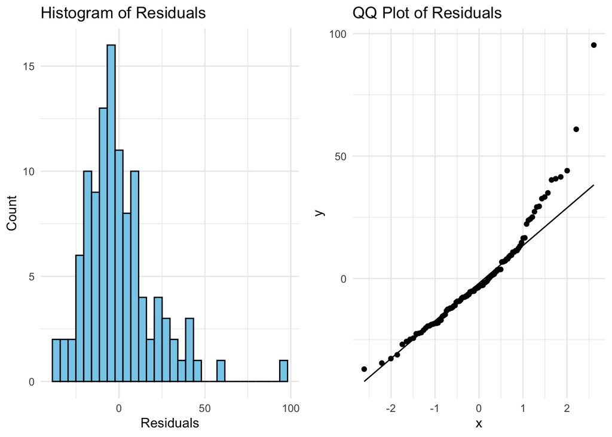

```r
hist_residuals <- ggplot(model_data, aes(.resid)) +
  geom_histogram(bins = 30, fill = "skyblue", color = "black") +
  theme_minimal() +
  labs(title = "Histogram of Residuals", x = "Residuals", y = "Count")

qq_residuals <- ggplot(model_data, aes(sample = .resid)) +
  stat_qq() +
  stat_qq_line() +
  theme_minimal() +
  labs(title = "QQ Plot of Residuals")

ggarrange(hist_residuals, qq_residuals, ncol = 2, nrow = 1)
```

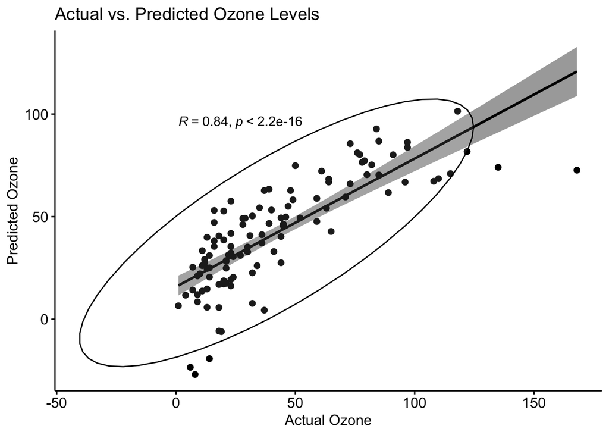

```r
ggscatter(model_data, x = "Ozone", y = ".fitted",
          add = "reg.line", conf.int = TRUE,
          cor.coef = TRUE, cor.method = "spearman",
          ellipse = TRUE) +
  labs(title = "Actual vs. Predicted Ozone Levels",
       x = "Actual Ozone",
       y = "Predicted Ozone")
```